# Gfk Rus, Test task

Kirill Guliev

07.09.2021

# Load libraries

Require libraries that I am going to use in data analysis and data manipulation sections

```r
library(tidyverse) # a basic library for manipulation and analysis
library(data.table) # just for reading files, best speed benchmarks
library(lubridate) # to manage time
library(zoo) # the same puprose
library(gganimate)
```

Then we are going to read our data. I will use `data.table` package and `fread` function to read `.csv` and `.tsv` files. Also, I will join to dataframes and convert the `movedate` variable to a date format.

```r
dem_data <- data.table::fread("./data/demography_data.csv")

purchase <- data.table::fread("./data/purchase_data.tsv")

joined_data <- purchase %>%
  inner_join(dem_data, by = "hhkey") %>%
  mutate(movedate = as.yearmon(as.Date(ymd(movedate))))
```

So, I am going to complete all the tasks. Here and forth I will put my own comments. Do not pay much attention to them.

## 1. Share of repeated purchases in the category

Group by date to find out the number of buyers in a current period of time. Also, group by the buyer’s ID and calculate the number of a distinct operation

```r
repeated_purchases <- joined_data %>%
  group_by(movedate, hhkey) %>%
  summarise(repeated = n_distinct(occaskey)) %>%
  arrange(desc(repeated)) %>%
  ungroup() %>%
  mutate(share = round((repeated / sum(repeated)) * 100, 2))
head(repeated_purchases, 5)
```

| movedate | hhkey | repeated | share |
| --- | --- | --- | --- |
| фев 2015 | 2108ed2dc4452b618a4fa5f9f96b2854 | 5 | 0.04 |
| июн 2015 | fa13ee0842278b576650dcff1e9f18ff | 5 | 0.04 |
| июл 2015 | f82630e98027b7db21ae2a118f043ca7 | 5 | 0.04 |
| фев 2015 | c89f04569c10f8dfb394d10c95390e5e | 4 | 0.03 |
| апр 2015 | d5efc4b0aa30a1cd7aaa0adaa1959753 | 4 | 0.03 |

## 2. Divide buyers by tertiles into 3 groups - heavy, medium, light

Division should correspond with cumulative spending. Compute tertiles among repeated buyers; find out the share of each group among the repeated buyers

```r
grouped <- repeated_purchases %>%
  filter(repeated >= 2) %>%
  select(hhkey) %>%
  distinct() %>%
  inner_join(joined_data, by = "hhkey") %>%
  select(hhkey, occaskey, value, number) %>%
  group_by(hhkey) %>%
  summarise(cumulative_spending = sum(value)) %>%
  ungroup()

tertiles <- quantile(grouped$cumulative_spending, c(0:3 / 3))

grouped$group <- with(grouped,
                       cut(cumulative_spending,
                       tertiles,
                       include.lowest = T,
                       lables = c("heavy", "medium", "light")))

levels(grouped$group) <- c("light", "medium", "heavy")

arranged_grouped <- grouped %>%
  arrange(desc(cumulative_spending))

final_grouped <- grouped %>%
  group_by(group) %>%
  summarise(n_per_group = n_distinct(hhkey)) %>%
  ungroup() %>%
  mutate(share_per_group = round((n_per_group / sum(n_per_group)) * 100, 2))

head(final_grouped)
```

| group | n_per_group | share_per_group |
| --- | --- | --- |
| light | 232 | 33.43 |
| medium | 231 | 33.29 |
| heavy | 231 | 33.29 |

```r
cart_volume <- arranged_grouped %>%
  inner_join(joined_data, by = "hhkey") %>%
  select(hhkey, occaskey, value, number, federatio) %>%
  group_by(federatio) %>%
  summarise(mean_cart_volume = mean(value, na.rm = TRUE)) %>%
  ungroup() %>%
  arrange(desc(mean_cart_volume))

head(cart_volume, 9)
```

| federatio | mean_cart_volume |
| --- | --- |
| Far East | 60.08298 |
| St.Petersburg | 56.69910 |
| Moscow | 55.96530 |
| Siberia | 55.66582 |
| Central | 49.26343 |
| Privolzhie | 48.98085 |
| North-West | 46.03513 |
| South | 45.63598 |
| Ural | 44.42664 |

## 4. Plotting general and variate monthly spending

Plotting monthly spending by regions - this is my initiative. I thought it will be interesting to see in what regions people spend more on garbage bags monthly

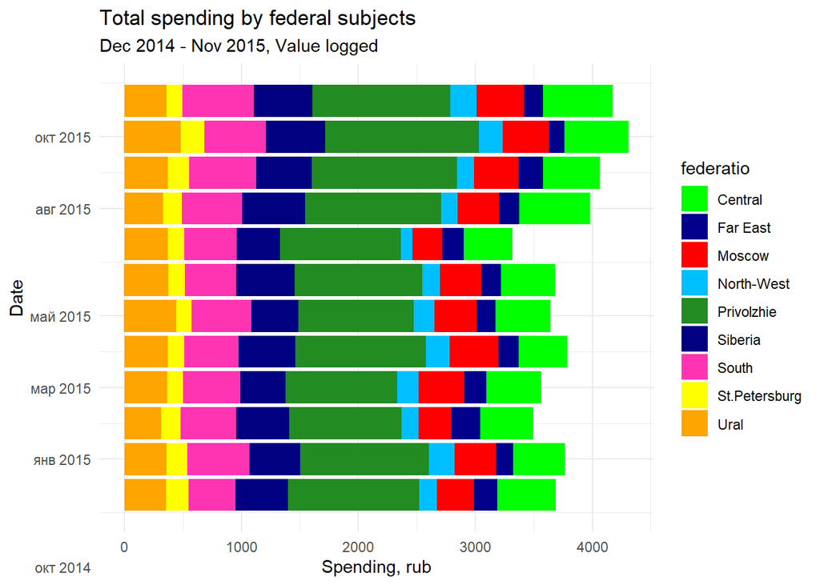

```r
plot_data <- joined_data %>%
  select(hhkey, occaskey, movedate, value, channel, federatio) %>%
  arrange(desc(movedate)) %>%
  mutate(value = log(value))

# Plot: total spending

ggplot(plot_data, aes(x = movedate, y = value, fill = federatio)) +
  geom_col() +
  theme_minimal() +
  coord_flip() +
  scale_fill_manual(
    values = c(
      "Central" = "green",
      "Far East" = "blue4",
      "Moscow" = "red",
      "North-West" = "deepskyblue",
      "Privolzhie" = "forestgreen",
      "Siberia" = "navy",
      "South" = "maroon1",
      "St.Petersburg" = "yellow",
      "Ural" = "orange"
    ),
    labels = c(
      "Central",
      "Far East",
      "Moscow",
      "North-West",
      "Privolzhie",
      "Siberia",
      "South",
      "St.Petersburg",
      "Ural"
    )
  ) +
  ggtitle(
    label = "Total spending by federal subjects",
    subtitle = "Dec 2014 - Nov 2015, Value logged"
  ) +
  ylab("Spending, rub") +
  xlab("Date")
```

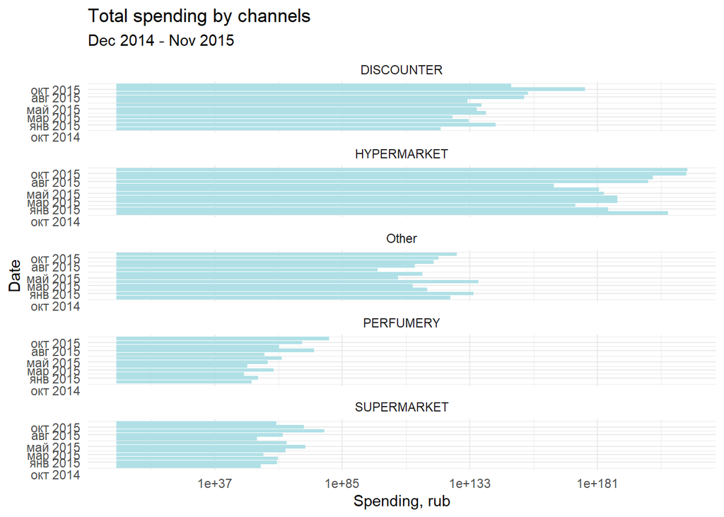

```r
# Plot: by channel

ggplot(plot_data, aes(x = movedate, y = value)) +
  geom_col(fill = "powderblue") +
  scale_y_log10() +
  theme_minimal() +
  coord_flip() +
  ggtitle(
    label = "Total spending by channels",
    subtitle = "Dec 2014 - Nov 2015"
  ) +
  ylab("Spending, rub") +
  xlab("Date") +
  facet_wrap(~ channel, ncol = 1)
```

## 5. variant variable grouping

Groups were decided according to the mean value (spending). There are five groups of garbage bags variants which represent their popularity (the amount of money that buyer is ready to spend on them)

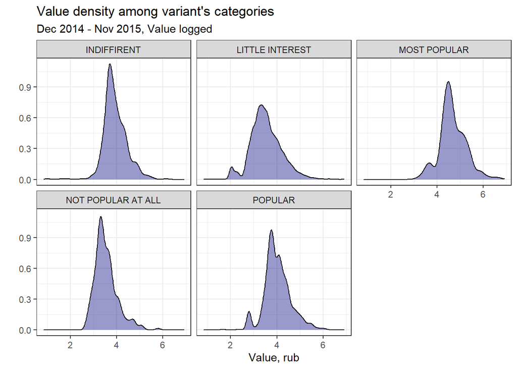

```r
grouping_Variant <- joined_data %>%
  select(hhkey, occaskey, value, number, variant, federatio) %>%
  group_by(variant) %>%
  summarise(MEAN = mean(value, na.rm = TRUE)) %>%
  ungroup() %>%
  arrange(desc(MEAN)) %>%
  mutate(category = ntile(MEAN, 5),
         category = ifelse(category == 5, "MOST POPULAR", ifelse(category == 4, "POPULAR",
                                                                 ifelse(category == 3, "INDIFFIRENT",
                                                                        ifelse(category == 2, "LITTLE INTEREST", "NOT POPULAR AT ALL"))))) %>%
select(variant, category)


plot_data2 <- grouping_Variant %>%
  inner_join(joined_data, by = "variant") %>%
  select(hhkey, occaskey, value, variant, category) %>%
  mutate(value = log(value))

# Density of value, rub, by categories

ggplot(plot_data2, aes(value)) +
  geom_density(fill = "navy", alpha = 0.4) +
  facet_wrap(~ category, nrow = 2) +
  theme_bw() +
  ggtitle(label = "Value density among variant's categories",
          subtitle = "Dec 2014 - Nov 2015, Value logged") +
  xlab("Value, rub") +
  ylab("")
```